# Assignment 3: Model comparison

Marton Kovacs

In this lab assignment you are going to work with (simulated) data related to perioperative pain and its psychological and hormonal predictors. In the assignment you will assess the added benefit of including some psychological and hormonal predictors to the already established demographic predictors of pain.

In this assignment you will set up a hierarchical regression model to predict postoperative pain after wisdom tooth surgery.

# Research problem

The amount of pain experienced around and after surgeries are highly variable between and within individuals. In order to improve surgical pain management regimens we need to understand what influences pain around surgical procedures and predict the amount of pain an individual will experience.

Your first study in this area is related to assessing the influence of trait and state psychological measures on pain, and to see whether taking into account these variables can improve our understanding of postoperative pain.

# Procedures and measures

Use the data file called ‘assignment_3_dataset’, from the ‘data/’ folder.

You have collected data from 160 adults who were scheduled to undergo surgical extraction of the third mandibular molar (wisdom tooth surgery). Patients filled out a form in the waiting room before their surgery. The form contained questions about their sex, age, and weight, and psychological questionnaires assessing anxiety, pain catastrophizing, and mindfulness (see descriptions below). You also got blood samples and saliva samples from participants in the waiting room 5 minutes before their operations to determine the serum (a component of the blood) and salivary cortisol levels of participants. Participants were contacted 5 hours after the surgery to see how much pain they were experiencing. The **level of pain** at that moment was recorded using a numerical rating scale using a **scale of 0 to 10**, where 0 means “no pain” and 10 means “worst pain I can imagine”.

**The State Trait Anxiety Inventory:** T measures trait anxiety on a scale of 20 to 80, higher scores mean higher anxiety. Anxiety has been found in many studies to positively correlate with the level of pain experienced. This is **variable STAI_trait** in the dataset.

**The Pain Catastrophizing Scale** measures the extent of pain catastrophizing, which is characterized by a tendency to magnify the threat value of a pain stimulus and to feel helpless in the presence of pain, as well as by a relative inability to prevent or inhibit pain-related thoughts in anticipation of, during, or following a painful event. The total score on this scale ranges from 0 to 52, higher scores mean higher catastrophizing. Pain catastrophizing is one of the well-established predictors of clinical pain. This is **variable pain_cat** in the dataset.

**The Mindful Attention Awareness Scale (MAAS)** measures dispositional mindfulness, which may be described as a tendency to turn attention to present-moment experiences in an open, non-judgmental way. The MAAS total score ranges from 1 to 6 (an average of the item scores), with higher scores representing higher dispositional mindfulness. Trait mindfulness has been theorized to serve as a protective factor against pain, as the individual would be more objective about their pain experience and tend to associate less discomfort, despair, and hopelessness to the pain-related sensations. This is **variable mindfulness** in the dataset.

**Cortisol** is a stress hormone associated with acute and chronic stress. Cortisol levels are thought to be positively associated with pain experience. Cortisol can be **measured from both blood and the saliva**, although, serum cortisol is often regarded in medical research as more reliably related to stress (serum is a component of the blood plasma). These are **variables cortisol_serum**, and **cortisol_saliva** in the dataset.

# Research question

Previous studies and meta-analyses showed that age and sex are often predictors of pain (age is negatively associated with pain, while sex is a predictor more dependent on the type of the procedure). You would like to determine the extent to which taking into account psychological and hormonal variables aside from the already used demographic variables would improve our understanding of postoperative pain.

To answer this research question you will **need to compare two models** (with a hierarchical regression). The **simpler model** should contain **age and sex as predictors of pain**, while the **more complex model** should contain the **predictors: age, sex, STAI, pain catastrophizing, mindfulness, and cortisol measures**. Notice that the predictors used in the simpler model are a subset of the predictors used in more complex model. **You will have to do model comparison to assess whether substantial new information was gained about pain in the more complex model compared to the simpler model.**

# What to report

As usual, before you can interpret your model, you will need to run data and model diagnostics. First, check the variables included in the more complex model (age, sex, STAI, pain catastrophizing, mindfulness, and cortisol measures as predictors, and pain as an outcome) for **coding errors**, and the model itself for **influential outliers** (for example using Cook’s distance). Furthermore, check the final model to see if the **assumptions of linear regression hold true**, that is, **normality** (of the residuals), **linearity** (of the relationship), **homogeneity of variance** (also called homoscedasticity) and that there is no excess **multicollinearity** (“uncorrelated predictors” in Navarro’s words). If you find anything amiss during these checks, make the appropriate decision or correction and report your findings and actions in your report.

**Note:** If you do any changes, such as exclude cases, or exclude predictors from the model, you will have to re-run the above checks for your final data and model.

Report the results of the simpler model and the more complex model. For both models you should report the model test statistics (adj.R2, F, df, and p value). Also, report the statistics describing the coefficients of the predictors in a table format (unstandardized regression coefficients and 95% confidence intervals, standardized regression coefficients (B and Beta values), and p values).

Write up the regression equation of the more complex model in the form of 𝑌 = 𝑏0 + 𝑏1 ∗ X1 + 𝑏2 ∗ X2 +…+ bn * Xn, in which you use the actual regression coefficients of your models. (b0 stands for the intercept and b1, b2 … bn stand for the model coefficients for each of the predictors, and X1, X2, … Xn denote the predictors).

Compare the two models in terms of how much variance they explain of pain’s variability in the sample. Report Akaike information criterion (AIC) for both models and the F test statistic and p value of the likelihood ratio test comparing the two models.

# What to discuss

In your discussion of the findings, briefly interpret the results of the above analyses, and indicate whether you think that anything was gained by including the psychological and hormone measures in the model.

# Solution

## Read the data

Read the dataset used in this assignment. Pay attention to the extension of the datafile.

```r
# Loading necessary packages

library(tidyverse)
library(broom)
library(car)
library(lmtest)
```

```r
library(readxl)
library(ggcorrplot)
library(lm.beta)
library(ggfortify)

# Reading dataset

data <- read_excel("C:/Users/Acer/Desktop/SULI4/ELTE PSZICHOLÓGIA BA/2024-25-1 (1. FÉLÉV)/PSZM21-MO-KUT-104.2 - Komplex adatelemzési eljárások - Adatelemzés R-programnyelven/Assignment/Fall-2024/data/assignment_3_dataset_.xlsx")
```

## Data and model diagnostics

### Data diagnostics

#### Descriptives of the variables

Run an exploratory data analysis (EDA) to investigate the dataset.

```r
# Exploring dataset structure, summary statistics
str(data)
```

```
## tibble [160 × 12] (S3: tbl_df/tbl/data.frame)
##  $ ID              : chr [1:160] "ID_1" "ID_2" "ID_3" "ID_4" ...
##  $ pain            : num [1:160] 5 4 5 7 4 6 4 5 4 5 ...
##  $ sex             : chr [1:160] "female" "female" "female" "female" ...
##  $ age             : num [1:160] 38 36 51 39 48 45 45 35 39 33 ...
##  $ STAI_trait      : num [1:160] 39 46 49 48 36 37 34 39 31 38 ...
##  $ pain_cat        : num [1:160] 25 31 32 41 26 28 22 32 27 36 ...
##  $ cortisol_serum  : num [1:160] 4.67 6.01 5.18 6.65 2.95 4.32 5.32 5.26 3.36 5.96 ...
##  $ cortisol_saliva : num [1:160] 4.78 6.71 4.75 6.68 3.2 4.36 5.19 5.53 3.3 5.78 ...
##  $ mindfulness     : num [1:160] 3.83 2.82 3.93 1.9 4.39 3.01 4.97 2.95 3.43 1.85 ...
##  $ weight          : num [1:160] 62.1 97.1 79 78.5 76.9 ...
##  $ IQ              : num [1:160] 99 71 97 97 129 115 74 98 93 76 ...
##  $ household_income: num [1:160] 52505 64993 68598 47822 100580 ...
```

```r
sum(is.na(data))
```

```
## [1] 0
```

```r
summary(data)
```

```
##       ID                 pain            sex                 age
##  Length:160         Min.   : 1.000   Length:160         Min.   :24.00
##  Class :character   1st Qu.: 4.000   Class :character   1st Qu.:38.00
##  Mode  :character   Median : 5.000   Mode  :character   Median :41.00
##                     Mean   : 5.194                      Mean   :40.74
##                     3rd Qu.: 6.000                      3rd Qu.:44.00
##                     Max.   :50.000                      Max.   :53.00
##    STAI_trait       pain_cat     cortisol_serum  cortisol_saliva
##  Min.   :26.00   Min.   :14.00   Min.   :2.700   Min.   :2.530
##  1st Qu.:37.00   1st Qu.:27.00   1st Qu.:4.268   1st Qu.:4.120
##  Median :40.00   Median :30.00   Median :4.995   Median :5.035
##  Mean   :40.09   Mean   :29.88   Mean   :4.941   Mean   :4.952
##  3rd Qu.:43.00   3rd Qu.:32.25   3rd Qu.:5.633   3rd Qu.:5.753
##  Max.   :52.00   Max.   :42.00   Max.   :7.110   Max.   :7.190
##   mindfulness        weight            IQ         household_income
##  Min.   :1.000   Min.   :33.80   Min.   : 52.00   Min.   :  5548
##  1st Qu.:2.595   1st Qu.:62.15   1st Qu.: 91.75   1st Qu.: 53489
##  Median :3.115   Median :68.77   Median :101.00   Median : 72149
##  Mean   :3.204   Mean   :68.57   Mean   :100.74   Mean   : 70426
##  3rd Qu.:3.830   3rd Qu.:74.65   3rd Qu.:109.00   3rd Qu.: 87734
##  Max.   :6.220   Max.   :97.13   Max.   :144.00   Max.   :139268
```

```r
standard_deviations <- data %>%
   summarize(
    sd_pain = sd(pain),
    sd_age = sd(age),
    sd_STAI_trait = sd(STAI_trait),
    sd_pain_cat = sd(pain_cat),
    sd_cortisol_serum = sd(cortisol_serum),
    sd_cortisol_saliva = sd(cortisol_saliva),
    sd_mindfulness = sd(mindfulness),
    sd_weight = sd(weight),
    sd_IQ = sd(IQ),
    sd_household_income = sd(household_income)
    )

standard_deviations
```

```
## # A tibble: 1 × 10
##   sd_pain sd_age sd_STAI_trait sd_pain_cat sd_cortisol_serum sd_cortisol_saliva
##     <dbl>  <dbl>         <dbl>       <dbl>             <dbl>              <dbl>
## 1    3.87   5.04          5.15        4.78             0.992               1.01
## # ℹ 4 more variables: sd_mindfulness <dbl>, sd_weight <dbl>, sd_IQ <dbl>,
## #   sd_household_income <dbl>
```

```r
# Sex

is.factor(data$sex)
```

```
## [1] FALSE
```

```r
table(data$sex)
```

```
##
## female   male  woman
##     83     76      1
```

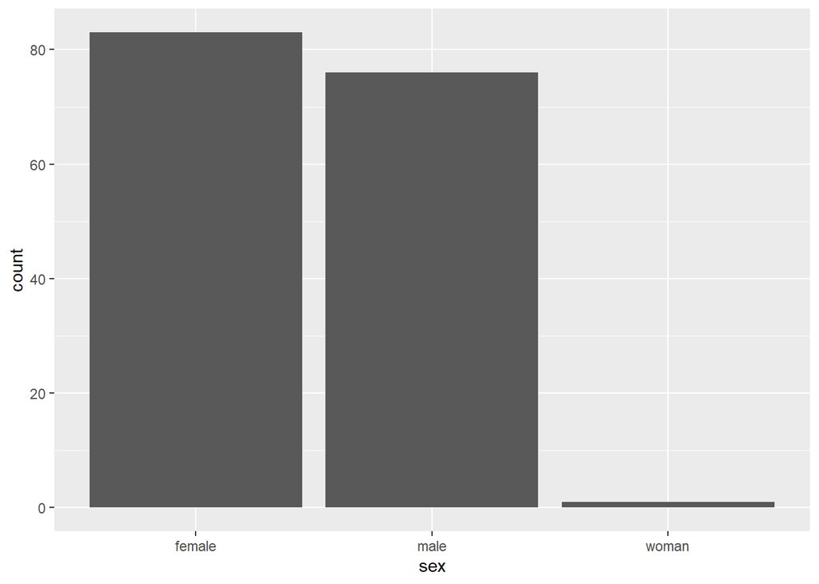

```r
ggplot(data, aes(sex)) +
  geom_bar()
```

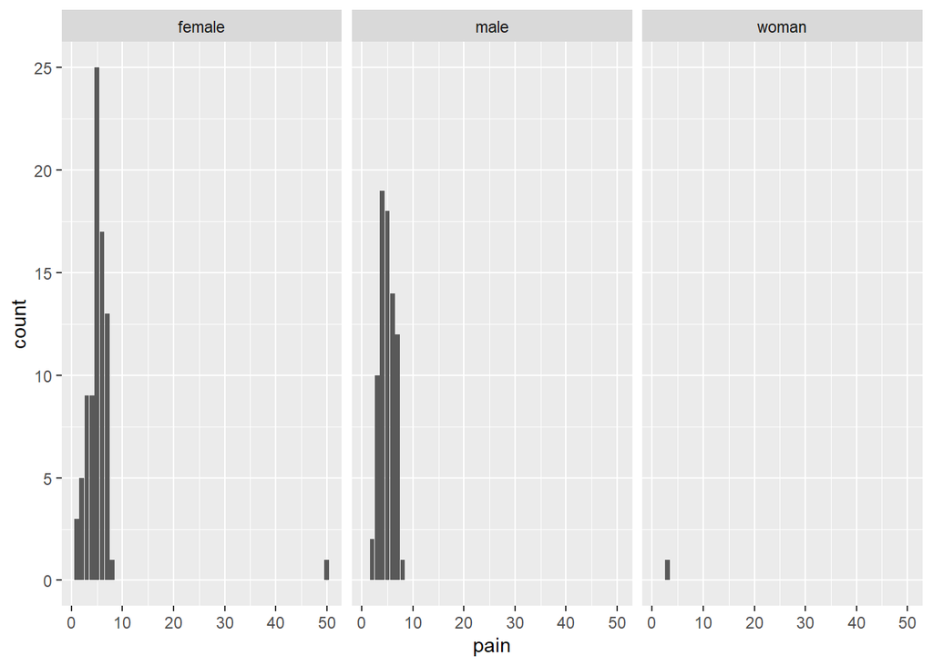

```r
ggplot(data, aes(pain)) +
  geom_bar() +
  facet_wrap(~ sex)
```

```r
pain_summary <- data %>%
  group_by(sex) %>%
  summarize(
    mean_pain = mean(pain),
    mean_age = mean(age),
    mean_STAI_trait = mean(STAI_trait),
    mean_pain_cat = mean(pain_cat),
    mean_cortisol_serum = mean(cortisol_serum),
    mean_cortisol_saliva = mean(cortisol_saliva),
    mean_mindfulness = mean(mindfulness),
    mean_weight = mean(weight),
    mean_IQ = mean(IQ),
    mean_household_income = mean(household_income)
    )

pain_summary
```

```
## # A tibble: 3 × 11
##   sex    mean_pain mean_age mean_STAI_trait mean_pain_cat mean_cortisol_serum
##   <chr>      <dbl>    <dbl>           <dbl>         <dbl>               <dbl>
## 1 female      5.45     40.4            41.4          30.0                5.16
## 2 male        4.95     40.9            38.6          29.9                4.72
## 3 woman       3        53              40            22                  3.53
## # ℹ 5 more variables: mean_cortisol_saliva <dbl>, mean_mindfulness <dbl>,
## #   mean_weight <dbl>, mean_IQ <dbl>, mean_household_income <dbl>
```

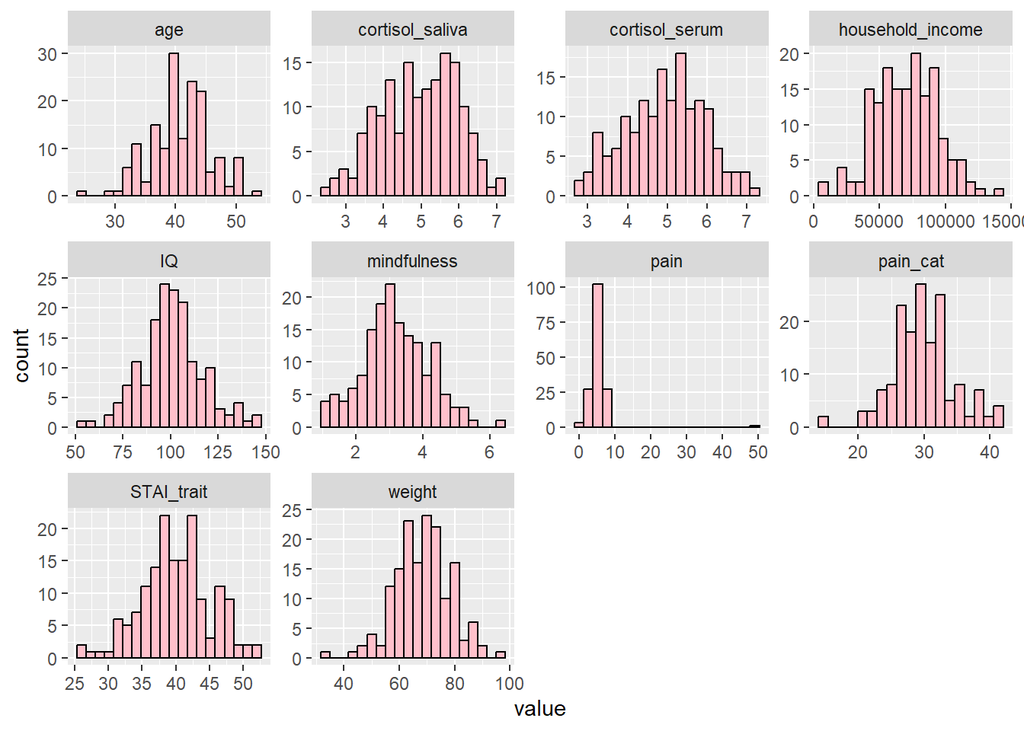

```r
# Distribution of continuous variables

data_long <- data %>%
  pivot_longer(cols = c(pain, age, STAI_trait, pain_cat, cortisol_serum, cortisol_saliva, mindfulness, weight, IQ, household_income),
               names_to = "variable",
               values_to = "value")

ggplot(data_long, aes(value)) +
  geom_histogram(bins = 20, fill = "pink", color = "black") +
  facet_wrap(~ variable, scales = "free")
```

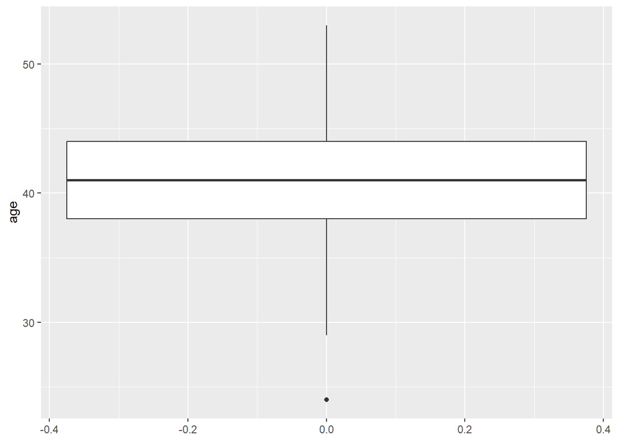

```r
# Checking for outliers with boxplots

ggplot(data, aes(age)) +
  geom_boxplot() +
  coord_flip()
```

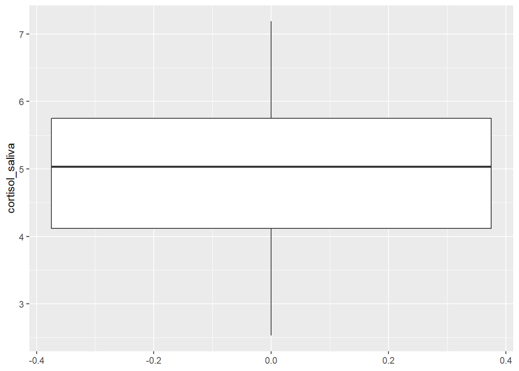

```r
ggplot(data, aes(cortisol_saliva)) +
  geom_boxplot() +
  coord_flip()
```

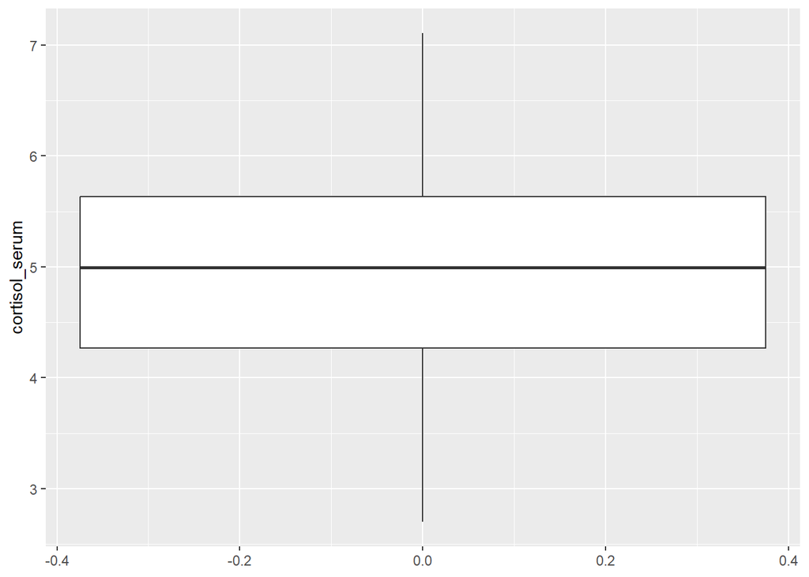

```r
ggplot(data, aes(cortisol_serum)) +
  geom_boxplot() +
  coord_flip()
```

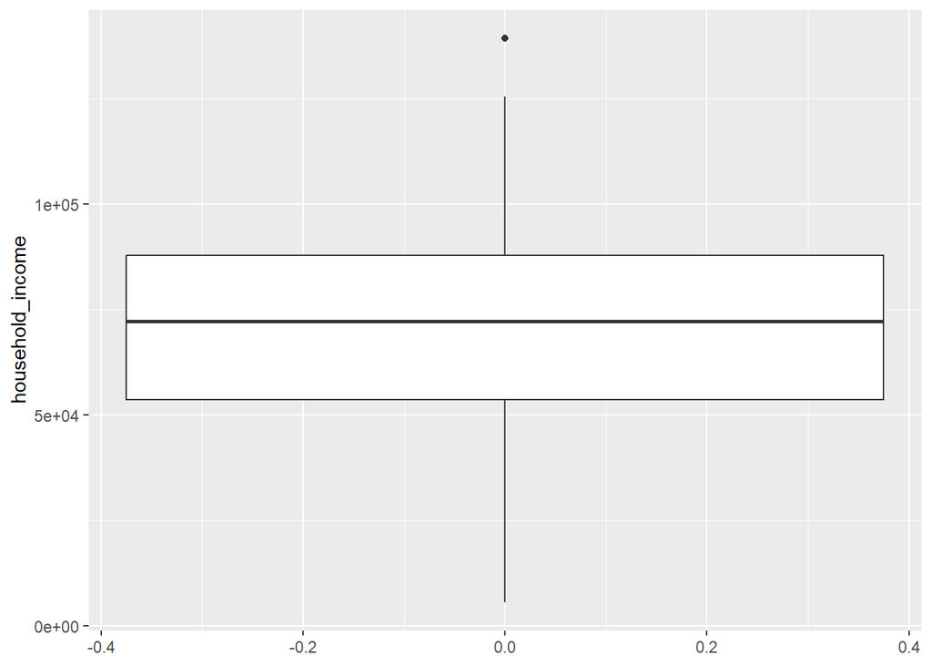

```r
ggplot(data, aes(household_income)) +
  geom_boxplot() +
  coord_flip()
```

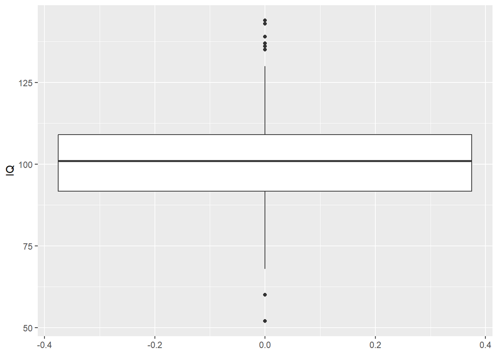

```r
ggplot(data, aes(IQ)) +
  geom_boxplot() +
  coord_flip()
```

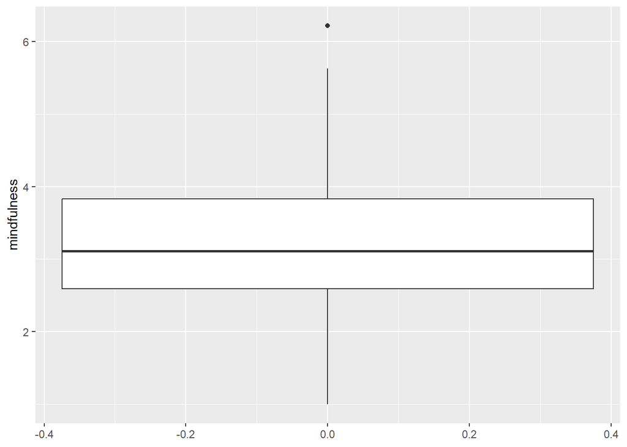

```r
ggplot(data, aes(mindfulness)) +
  geom_boxplot() +
  coord_flip()
```

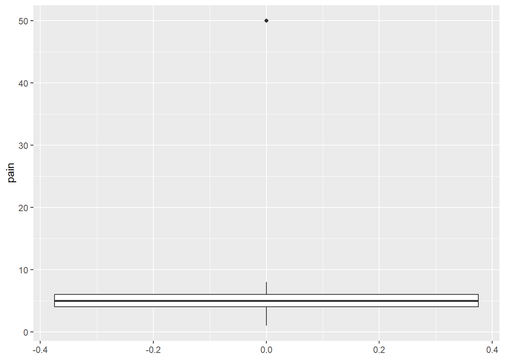

```r
ggplot(data, aes(pain)) +
  geom_boxplot() +
  coord_flip()
```

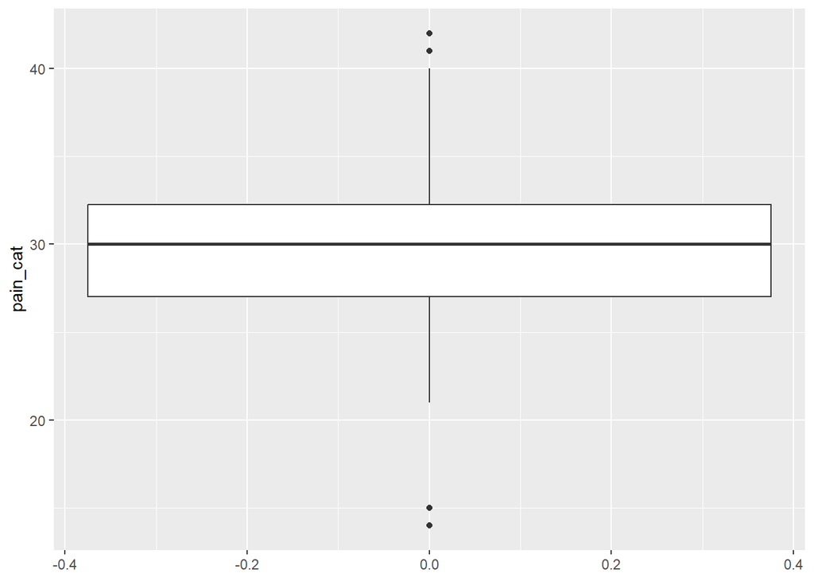

```r
ggplot(data, aes(pain_cat)) +
  geom_boxplot() +
  coord_flip()
```

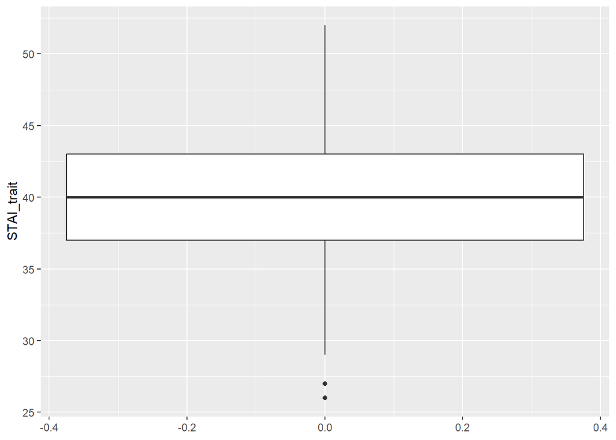

```r
ggplot(data, aes(STAI_trait)) +
  geom_boxplot() +
  coord_flip()
```

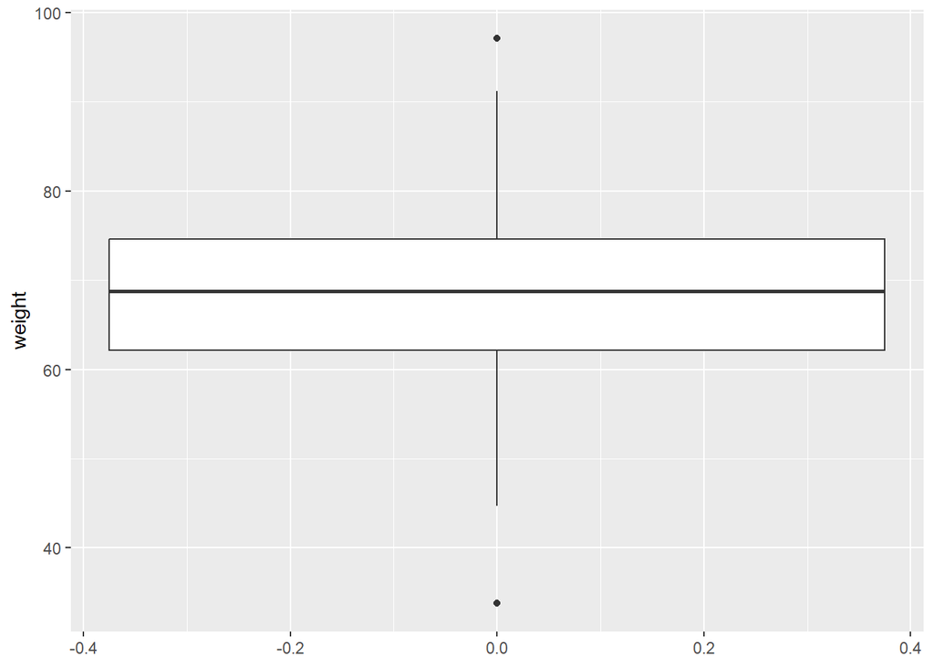

```r
ggplot(data, aes(weight)) +
  geom_boxplot() +
  coord_flip()
```

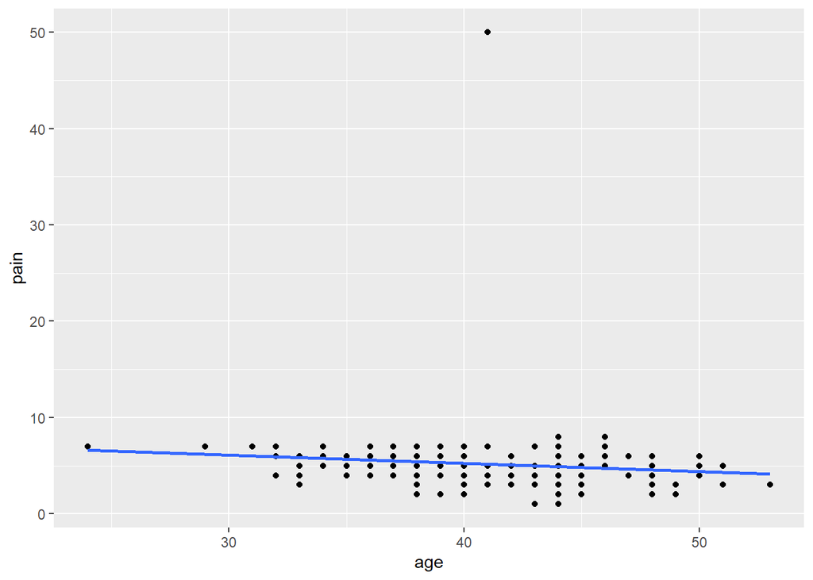

```r
# Visualizing connection between pain and age

ggplot(data, aes(age, pain)) +
  geom_point() +
  geom_smooth(method = "lm", se = FALSE)
```

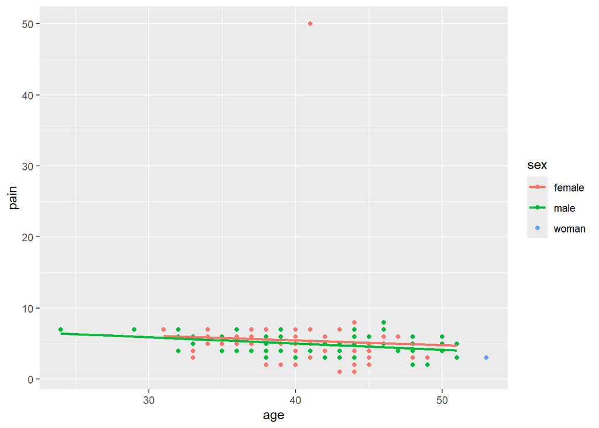

```r
ggplot(data, aes(age, pain, color = sex)) +
  geom_point() +
  geom_smooth(method = "lm", se = FALSE)
```

```r
# Checking for correlation between continuous variables

continuous_variables_for_correlation <- data %>%
  select(pain, age, STAI_trait, pain_cat, cortisol_serum, cortisol_saliva, mindfulness, weight, IQ, household_income)

correlation_matrix <- cor(continuous_variables_for_correlation)
print(correlation_matrix)
```

```
##                         pain         age  STAI_trait    pain_cat cortisol_serum
## pain              1.00000000 -0.11169716  0.15194048  0.18749586     0.25669939
## age              -0.11169716  1.00000000  0.13603514 -0.29131131    -0.27929271
## STAI_trait        0.15194048  0.13603514  1.00000000  0.47306554     0.45187839
## pain_cat          0.18749586 -0.29131131  0.47306554  1.00000000     0.41304651
## cortisol_serum    0.25669939 -0.27929271  0.45187839  0.41304651     1.00000000
## cortisol_saliva   0.27533663 -0.31208976  0.48887531  0.36645810     0.90901149
## mindfulness      -0.11443168 -0.01377820 -0.48144233 -0.49872338    -0.33332308
## weight            0.04386053 -0.04854128 -0.06086945  0.02059712     0.02881806
## IQ                0.05103984 -0.01798365 -0.12332153 -0.11660523    -0.15445532
## household_income  0.02153228 -0.05190531  0.05982693 -0.07259303     0.08020706
##                  cortisol_saliva mindfulness      weight          IQ
## pain                  0.27533663  -0.1144317  0.04386053  0.05103984
## age                  -0.31208976  -0.0137782 -0.04854128 -0.01798365
## STAI_trait            0.48887531  -0.4814423 -0.06086945 -0.12332153
## pain_cat              0.36645810  -0.4987234  0.02059712 -0.11660523
## cortisol_serum        0.90901149  -0.3333231  0.02881806 -0.15445532
## cortisol_saliva       1.00000000  -0.3349702  0.03200715 -0.17206629
## mindfulness          -0.33497025   1.0000000  0.10944473  0.21232891
## weight                0.03200715   0.1094447  1.00000000  0.04479603
## IQ                   -0.17206629   0.2123289  0.04479603  1.00000000
## household_income      0.04866947   0.1662021  0.18212169  0.06276692
##                  household_income
## pain                   0.02153228
## age                   -0.05190531
## STAI_trait             0.05982693
## pain_cat              -0.07259303
## cortisol_serum         0.08020706
## cortisol_saliva        0.04866947
## mindfulness            0.16620206
## weight                 0.18212169
## IQ                     0.06276692
## household_income       1.00000000
```

```r
p_mat <- cor_pmat(continuous_variables_for_correlation)
print(p_mat)
```

```
##                          pain          age   STAI_trait     pain_cat
## pain             0.0000000000 1.596659e-01 5.511181e-02 1.758916e-02
## age              0.1596658662 0.000000e+00 8.630592e-02 1.859873e-04
## STAI_trait       0.0551118116 8.630592e-02 0.000000e+00 2.669072e-10
## pain_cat         0.0175891572 1.859873e-04 2.669072e-10 0.000000e+00
## cortisol_serum   0.0010504913 3.481647e-04 1.998302e-09 5.697035e-08
## cortisol_saliva  0.0004253776 5.881409e-05 5.418775e-11 1.880328e-06
## mindfulness      0.1496278496 8.627114e-01 1.158420e-10 1.924563e-11
## weight           0.5818312149 5.421604e-01 4.444997e-01 7.960057e-01
## IQ               0.5215457106 8.214256e-01 1.202767e-01 1.419951e-01
## household_income 0.7869602251 5.144994e-01 4.523534e-01 3.616414e-01
##                  cortisol_serum cortisol_saliva  mindfulness     weight
## pain               1.050491e-03    4.253776e-04 1.496278e-01 0.58183121
## age                3.481647e-04    5.881409e-05 8.627114e-01 0.54216039
## STAI_trait         1.998302e-09    5.418775e-11 1.158420e-10 0.44449971
## pain_cat           5.697035e-08    1.880328e-06 1.924563e-11 0.79600569
## cortisol_serum     0.000000e+00    6.117828e-62 1.654802e-05 0.71754646
## cortisol_saliva    6.117828e-62    0.000000e+00 1.493780e-05 0.68783819
## mindfulness        1.654802e-05    1.493780e-05 0.000000e+00 0.16830640
## weight             7.175465e-01    6.878382e-01 1.683064e-01 0.00000000
## IQ                 5.116149e-02    2.957966e-02 7.027886e-03 0.57379609
## household_income   3.133495e-01    5.410931e-01 3.568873e-02 0.02117072
##                           IQ household_income
## pain             0.521545711       0.78696023
## age              0.821425578       0.51449940
## STAI_trait       0.120276675       0.45235336
## pain_cat         0.141995142       0.36164137
## cortisol_serum   0.051161494       0.31334953
## cortisol_saliva  0.029579656       0.54109308
## mindfulness      0.007027886       0.03568873
## weight           0.573796094       0.02117072
## IQ               0.000000000       0.43040515
## household_income 0.430405149       0.00000000
```

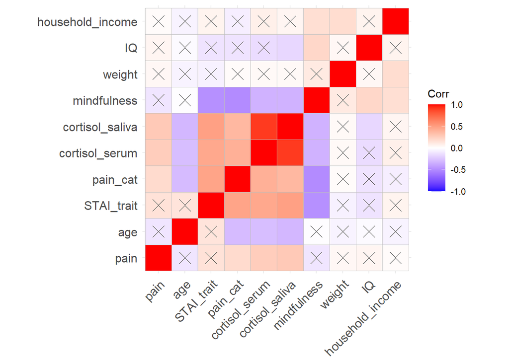

```r
ggcorrplot(correlation_matrix, p.mat = p_mat, lab = FALSE)
```

#### Correct coding errors

If you find values in the dataset during the EDA, that are not correct based on the provided descriptions of the variables of the dataset please correct them here.

```r
# Sex as factor + recoding

data <- data %>%
  mutate(sex = ifelse(sex == "woman", "female", sex)) %>%
  mutate(sex = factor(sex))

is.factor(data$sex)
```

```
## [1] TRUE
```

```r
# Filtering data that is out of given range

data_filtered <- data %>%
    filter(pain >= 0 & pain <= 10, mindfulness >= 1 & mindfulness <= 6)
```

### Model diagnostics

#### Build the more complex model

In order to test the more complex model for outliers and to test the assumptions first build the model.

```r
# Fitting the more complex model and summarizing the model's statistics

complex_model <- lm(pain ~ age + sex + STAI_trait + pain_cat + mindfulness + cortisol_serum + cortisol_saliva, data = data_filtered)

glance(complex_model)
```

```
## # A tibble: 1 × 12
##   r.squared adj.r.squared sigma statistic  p.value    df logLik   AIC   BIC
##       <dbl>         <dbl> <dbl>     <dbl>    <dbl> <dbl>  <dbl> <dbl> <dbl>
## 1     0.352         0.321  1.24      11.6 9.35e-12     7  -255.  527.  555.
## # ℹ 3 more variables: deviance <dbl>, df.residual <int>, nobs <int>
```

```r
summary(complex_model)
```

```
##
## Call:
## lm(formula = pain ~ age + sex + STAI_trait + pain_cat + mindfulness +
##     cortisol_serum + cortisol_saliva, data = data_filtered)
##
## Residuals:
##     Min      1Q  Median      3Q     Max
## -3.2406 -0.7463 -0.0537  0.7906  2.9380
##
## Coefficients:
##                 Estimate Std. Error t value Pr(>|t|)
## (Intercept)      1.29880    1.72907   0.751  0.45374
## age             -0.02142    0.02447  -0.875  0.38292
## sexmale          0.32267    0.21118   1.528  0.12863
## STAI_trait      -0.02814    0.02821  -0.998  0.32010
## pain_cat         0.09370    0.02889   3.243  0.00146 **
## mindfulness     -0.11768    0.12620  -0.933  0.35257
## cortisol_serum   0.16818    0.24576   0.684  0.49482
## cortisol_saliva  0.44738    0.25296   1.769  0.07900 .
## ---
## Signif. codes:  0 '***' 0.001 '**' 0.01 '*' 0.05 '.' 0.1 ' ' 1
##
## Residual standard error: 1.244 on 150 degrees of freedom
## Multiple R-squared:  0.3516, Adjusted R-squared:  0.3213
## F-statistic: 11.62 on 7 and 150 DF,  p-value: 9.351e-12
```

```r
tidy(complex_model, conf.int = TRUE)
```

```
## # A tibble: 8 × 7
##   term            estimate std.error statistic p.value conf.low conf.high
##   <chr>              <dbl>     <dbl>     <dbl>   <dbl>    <dbl>     <dbl>
## 1 (Intercept)       1.30      1.73       0.751 0.454    -2.12      4.72
## 2 age              -0.0214    0.0245    -0.875 0.383    -0.0698    0.0269
## 3 sexmale           0.323     0.211      1.53  0.129    -0.0946    0.740
## 4 STAI_trait       -0.0281    0.0282    -0.998 0.320    -0.0839    0.0276
## 5 pain_cat          0.0937    0.0289     3.24  0.00146   0.0366    0.151
## 6 mindfulness      -0.118     0.126     -0.933 0.353    -0.367     0.132
## 7 cortisol_serum    0.168     0.246      0.684 0.495    -0.317     0.654
## 8 cortisol_saliva   0.447     0.253      1.77  0.0790   -0.0525    0.947
```

```r
# Computing standardized beta coefficients

complex_model_standardized <- lm.beta(complex_model)
coef(complex_model_standardized)
```

```
##     (Intercept)             age         sexmale      STAI_trait        pain_cat
##              NA     -0.07134649      0.10700793     -0.09405620      0.28895924
##     mindfulness  cortisol_serum cortisol_saliva
##     -0.07425502      0.11039697      0.29860241
```

#### Checking for influential outliers

Check for outlier values in the model.

```r
# Cook's distance for the more complex model and checking for influential outliers (Cook's distance > 1)

cooks_distance_complex_model <- cooks.distance(complex_model)
influential_outliers_complex_model <- which(cooks_distance_complex_model > 1)
influential_outliers_complex_model
```

```
## named integer(0)
```

#### Checking assumptions

Check the normality assumption.

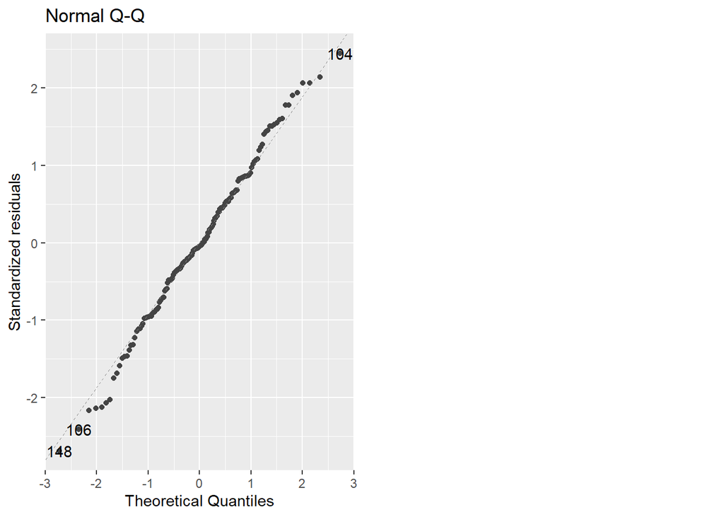

```r
# Q-Q plot for normality check

autoplot(complex_model, which = 2)
```

```r
# Compute leverage values and checking leverage for specific observations that deviate from the Q-Q plot line

leverage_values <- hatvalues(complex_model)
leverage_values[c(104, 106, 148)]
```

```
##        104        106        148
## 0.07028619 0.03660220 0.05843026
```

```r
# Viewing observations that might be influential

data_filtered[104, ]
```

```
## # A tibble: 1 × 12
##   ID      pain sex      age STAI_trait pain_cat cortisol_serum cortisol_saliva
##   <chr>  <dbl> <fct>  <dbl>      <dbl>    <dbl>          <dbl>           <dbl>
## 1 ID_105     7 female    38         38       21           5.46             4.9
## # ℹ 4 more variables: mindfulness <dbl>, weight <dbl>, IQ <dbl>,
## #   household_income <dbl>
```

```r
data_filtered[106, ]
```

```
## # A tibble: 1 × 12
##   ID      pain sex      age STAI_trait pain_cat cortisol_serum cortisol_saliva
##   <chr>  <dbl> <fct>  <dbl>      <dbl>    <dbl>          <dbl>           <dbl>
## 1 ID_107     2 female    39         34       30           4.77            4.99
## # ℹ 4 more variables: mindfulness <dbl>, weight <dbl>, IQ <dbl>,
## #   household_income <dbl>
```

```r
data_filtered[148, ]
```

```
## # A tibble: 1 × 12
##   ID      pain sex     age STAI_trait pain_cat cortisol_serum cortisol_saliva
##   <chr>  <dbl> <fct> <dbl>      <dbl>    <dbl>          <dbl>           <dbl>
## 1 ID_150     2 male     48         48       30           5.25            5.82
## # ℹ 4 more variables: mindfulness <dbl>, weight <dbl>, IQ <dbl>,
## #   household_income <dbl>
```

Check the linearity assumption.

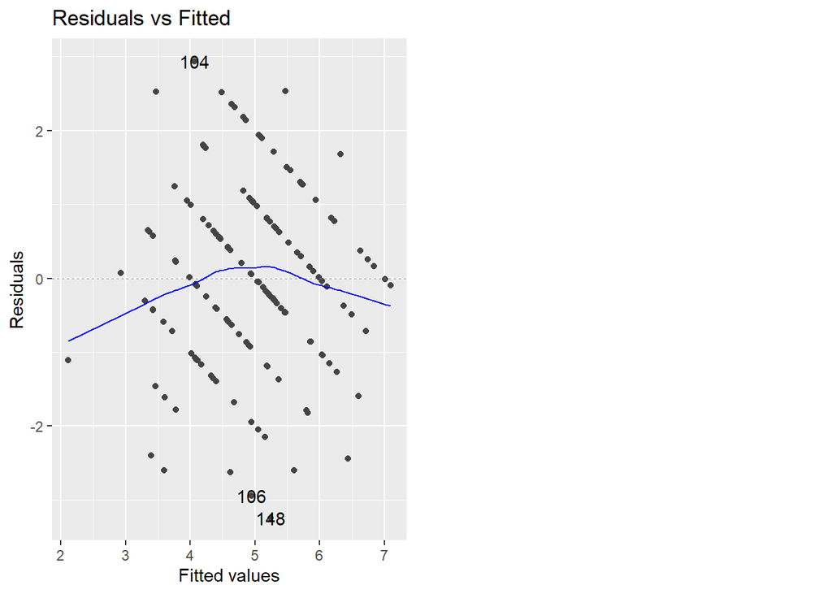

```r
# Residuals vs Fitted plot to check linearity

autoplot(complex_model, which = 1)
```

Check the homoscedasticty assumption (homogeneity of variance).

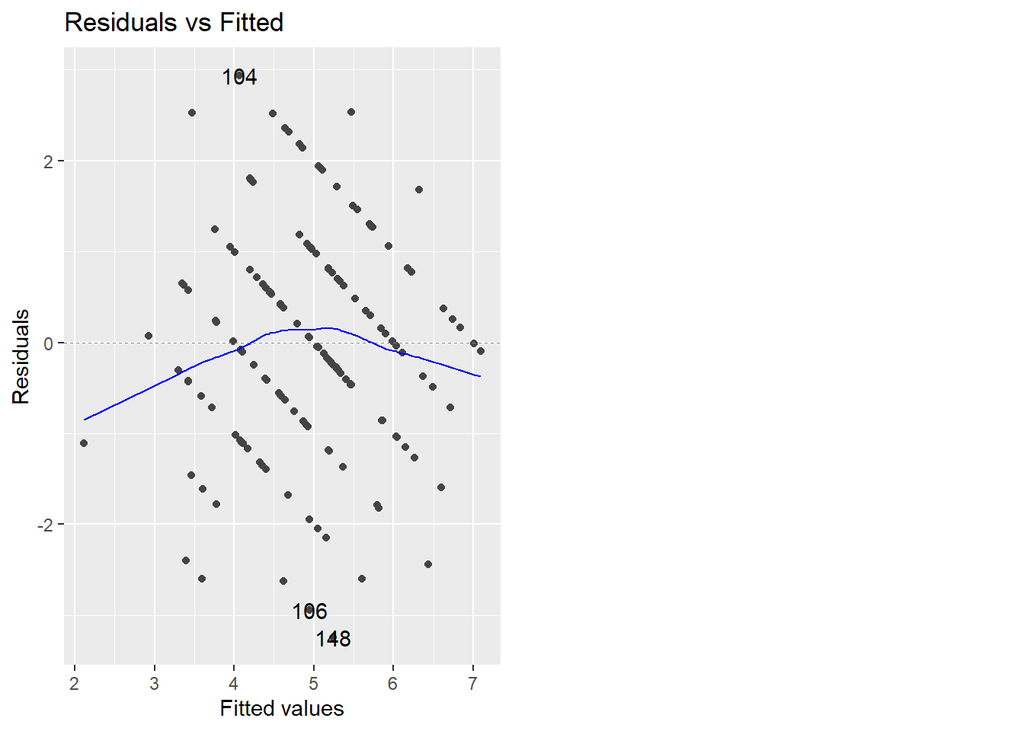

```r
# Residuals vs Fitted plot to check for homoscedasticity

autoplot(complex_model, which = 1)
```

Check the multicollinearity assumption.

(VIF above 5), or a VIF threshold of 3 is recommended in this paper: http://onlinelibrary.wiley.com/doi/10.1111/j.2041-210X.2009.00001.x/full

Some info about VIF: https://statisticalhorizons.com/multicollinearity http://blog.minitab.com/blog/understanding-statistics/handling-multicollinearity-in-regression-analysis

```r
# Calculating VIF values for complex model

vif(complex_model)
```

```
##             age             sex      STAI_trait        pain_cat     mindfulness
##        1.537752        1.134642        2.056568        1.836336        1.466876
##  cortisol_serum cortisol_saliva
##        6.020413        6.594781
```

```r
# Checking correlation between values of which VIF is > 5
cor(data_filtered$cortisol_saliva, data_filtered$cortisol_serum)
```

```
## [1] 0.9078928
```

### Making decision based on model diagnostics

If based on the assumption tests you decide to drop a predictor variable you should do that here. Create your updated model.

```r
# Fitting an updated complex model excluding cortisol_serum (due to lower estimate than cortisol_saliva) and summarizing the model's statistics

updated_complex_model <- lm(pain ~ age + sex + STAI_trait + pain_cat + mindfulness + cortisol_saliva, data = data_filtered)

glance(updated_complex_model)
```

```
## # A tibble: 1 × 12
##   r.squared adj.r.squared sigma statistic  p.value    df logLik   AIC   BIC
##       <dbl>         <dbl> <dbl>     <dbl>    <dbl> <dbl>  <dbl> <dbl> <dbl>
## 1     0.350         0.324  1.24      13.5 3.00e-12     6  -255.  526.  550.
## # ℹ 3 more variables: deviance <dbl>, df.residual <int>, nobs <int>
```

```r
summary(updated_complex_model)
```

```
##
## Call:
## lm(formula = pain ~ age + sex + STAI_trait + pain_cat + mindfulness +
##     cortisol_saliva, data = data_filtered)
##
## Residuals:
##     Min      1Q  Median      3Q     Max
## -3.3126 -0.7090 -0.0763  0.7986  3.0697
##
## Coefficients:
##                 Estimate Std. Error t value Pr(>|t|)
## (Intercept)      1.26406    1.72528   0.733 0.464897
## age             -0.01983    0.02432  -0.815 0.416079
## sexmale          0.31755    0.21067   1.507 0.133814
## STAI_trait      -0.02995    0.02803  -1.068 0.287073
## pain_cat         0.09812    0.02811   3.491 0.000632 ***
## mindfulness     -0.11636    0.12596  -0.924 0.357079
## cortisol_saliva  0.59683    0.12744   4.683 6.24e-06 ***
## ---
## Signif. codes:  0 '***' 0.001 '**' 0.01 '*' 0.05 '.' 0.1 ' ' 1
##
## Residual standard error: 1.242 on 151 degrees of freedom
## Multiple R-squared:  0.3496, Adjusted R-squared:  0.3237
## F-statistic: 13.53 on 6 and 151 DF,  p-value: 2.995e-12
```

```r
tidy(updated_complex_model, conf.int = TRUE)
```

```
## # A tibble: 7 × 7
##   term            estimate std.error statistic    p.value conf.low conf.high
##   <chr>              <dbl>     <dbl>     <dbl>      <dbl>    <dbl>     <dbl>
## 1 (Intercept)       1.26      1.73       0.733 0.465       -2.14      4.67
## 2 age              -0.0198    0.0243    -0.815 0.416       -0.0679    0.0282
## 3 sexmale           0.318     0.211      1.51  0.134       -0.0987    0.734
## 4 STAI_trait       -0.0299    0.0280    -1.07  0.287       -0.0853    0.0254
## 5 pain_cat          0.0981    0.0281     3.49  0.000632     0.0426    0.154
## 6 mindfulness      -0.116     0.126     -0.924 0.357       -0.365     0.133
## 7 cortisol_saliva   0.597     0.127      4.68  0.00000624   0.345     0.849
```

```r
# Computing standardized beta coefficients

updated_complex_model_standardized <- lm.beta(updated_complex_model)
coef(updated_complex_model_standardized)
```

```
##     (Intercept)             age         sexmale      STAI_trait        pain_cat
##              NA     -0.06607233      0.10531163     -0.10010842      0.30258620
##     mindfulness cortisol_saliva
##     -0.07342091      0.39835226
```

#### Checking outliers of the updated model

```r
# Cook's distance for the updated more complex model and checking for influential outliers (Cook's distance > 1)

cooks_distance_updated_complex_model <- cooks.distance(updated_complex_model)
influential_outliers_updated_complex_model <- which(cooks_distance_updated_complex_model > 1)
influential_outliers_updated_complex_model
```

```
## named integer(0)
```

#### Checking assumptions of the updated model

Normality assumption

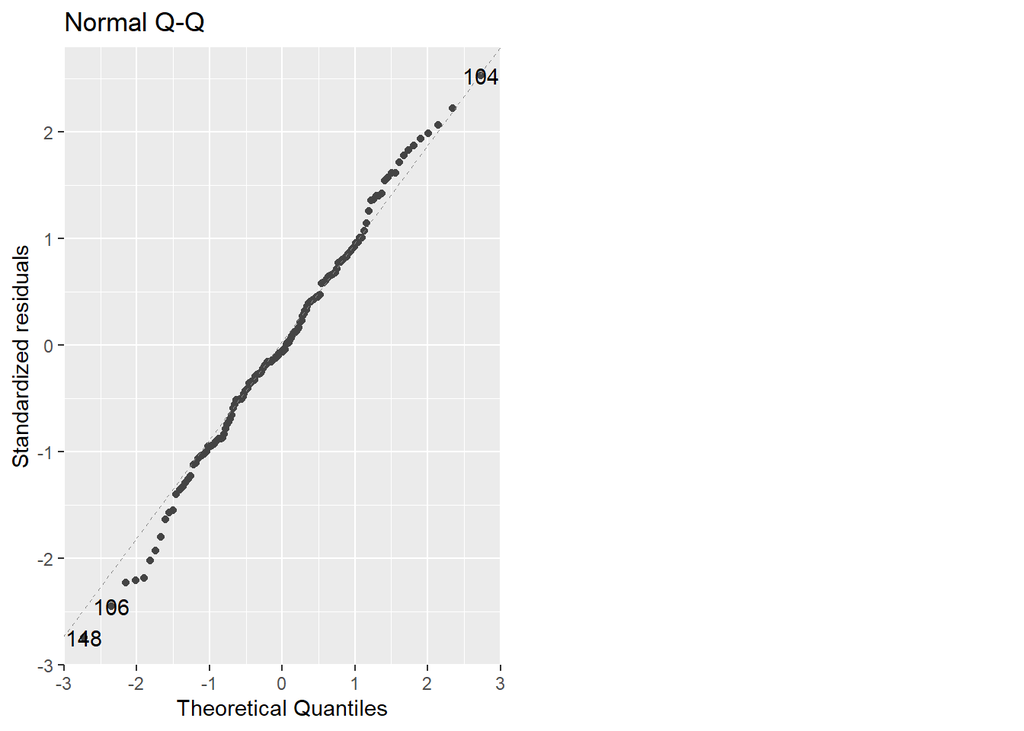

```r
# Q-Q plot for normality check

autoplot(updated_complex_model, which = 2)
```

```r
# Compute leverage values

leverage_values <- hatvalues(updated_complex_model)
leverage_values[c(106, 109, 148)]
```

```
##        106        109        148
## 0.03366834 0.07501316 0.05127928
```

```r
# Viewing observations that might be influential

data_filtered[106, ]
```

```
## # A tibble: 1 × 12
##   ID      pain sex      age STAI_trait pain_cat cortisol_serum cortisol_saliva
##   <chr>  <dbl> <fct>  <dbl>      <dbl>    <dbl>          <dbl>           <dbl>
## 1 ID_107     2 female    39         34       30           4.77            4.99
## # ℹ 4 more variables: mindfulness <dbl>, weight <dbl>, IQ <dbl>,
## #   household_income <dbl>
```

```r
data_filtered[109, ]
```

```
## # A tibble: 1 × 12
##   ID      pain sex     age STAI_trait pain_cat cortisol_serum cortisol_saliva
##   <chr>  <dbl> <fct> <dbl>      <dbl>    <dbl>          <dbl>           <dbl>
## 1 ID_110     4 male     37         41       31            6.9            6.29
## # ℹ 4 more variables: mindfulness <dbl>, weight <dbl>, IQ <dbl>,
## #   household_income <dbl>
```

```r
data_filtered[148, ]
```

```
## # A tibble: 1 × 12
##   ID      pain sex     age STAI_trait pain_cat cortisol_serum cortisol_saliva
##   <chr>  <dbl> <fct> <dbl>      <dbl>    <dbl>          <dbl>           <dbl>
## 1 ID_150     2 male     48         48       30           5.25            5.82
## # ℹ 4 more variables: mindfulness <dbl>, weight <dbl>, IQ <dbl>,
## #   household_income <dbl>
```

```r
# Since the observations that migth be influential are not impossibly out of range in any variable, I am not excluding them.
```

Linearity assumption

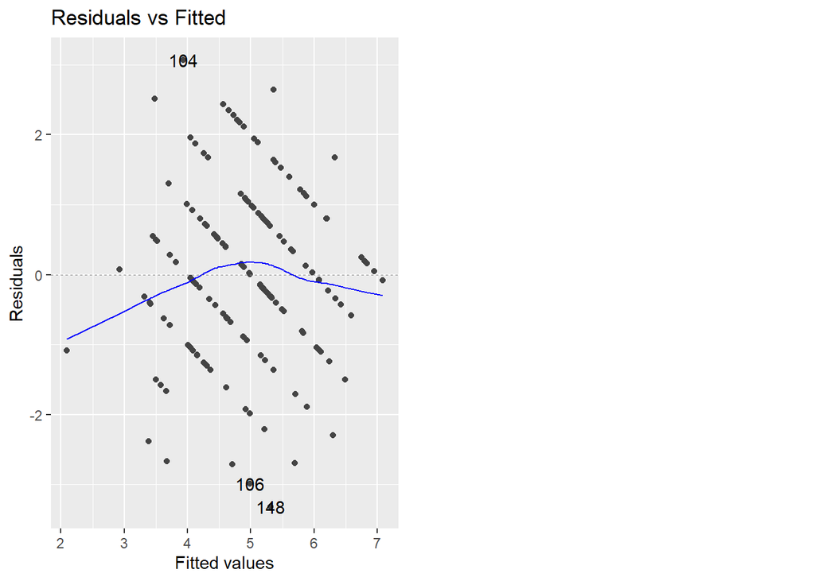

```r
# Residuals vs Fitted plot to check linearity

autoplot(updated_complex_model, which = 1)
```

Homoscedasticty assumption (homogeneity of variance)

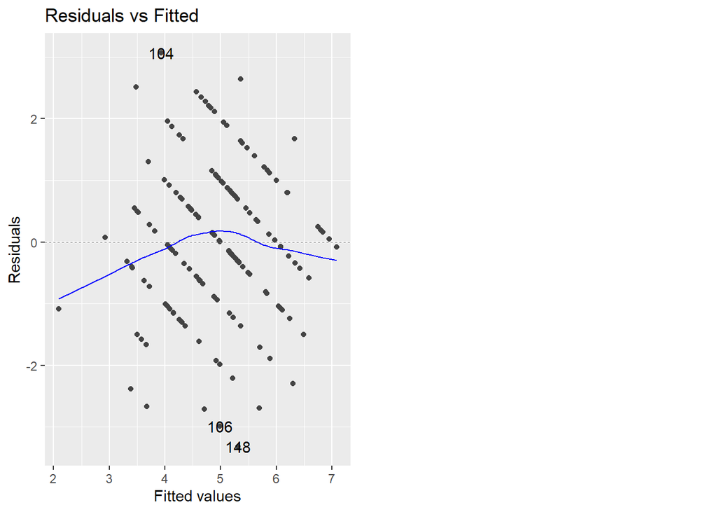

```r
# Residuals vs Fitted plot to check for homoscedasticity

autoplot(updated_complex_model, which = 1)
```

Multicollinearity assumption

```r
# Calculating VIF values for complex model

vif(updated_complex_model)
```

```
##             age             sex      STAI_trait        pain_cat     mindfulness
##        1.524011        1.133221        2.038473        1.744606        1.466532
## cortisol_saliva
##        1.679635
```

## Model comparison

Create the simple model and get the results of the model that needs to be reported based on the What to report section.

```r
# Fitting the simple model and summarizing the model's statistics

simple_model <- lm(pain ~ age + sex, data = data_filtered)

glance(simple_model)
```

```
## # A tibble: 1 × 12
##   r.squared adj.r.squared sigma statistic p.value    df logLik   AIC   BIC
##       <dbl>         <dbl> <dbl>     <dbl>   <dbl> <dbl>  <dbl> <dbl> <dbl>
## 1    0.0804        0.0685  1.46      6.78 0.00151     2  -282.  572.  585.
## # ℹ 3 more variables: deviance <dbl>, df.residual <int>, nobs <int>
```

```r
summary(simple_model)
```

```
##
## Call:
## lm(formula = pain ~ age + sex, data = data_filtered)
##
## Residuals:
##     Min      1Q  Median      3Q     Max
## -3.6729 -0.9614  0.1113  1.0105  3.4493
##
## Coefficients:
##             Estimate Std. Error t value Pr(>|t|)
## (Intercept)  8.30568    0.95157   8.728 3.85e-15 ***
## age         -0.08448    0.02313  -3.653 0.000355 ***
## sexmale      0.13129    0.23235   0.565 0.572853
## ---
## Signif. codes:  0 '***' 0.001 '**' 0.01 '*' 0.05 '.' 0.1 ' ' 1
##
## Residual standard error: 1.458 on 155 degrees of freedom
## Multiple R-squared:  0.08041,    Adjusted R-squared:  0.06855
## F-statistic: 6.777 on 2 and 155 DF,  p-value: 0.001508
```

```r
tidy(simple_model, conf.int = TRUE)
```

```
## # A tibble: 3 × 7
##   term        estimate std.error statistic  p.value conf.low conf.high
##   <chr>          <dbl>     <dbl>     <dbl>    <dbl>    <dbl>     <dbl>
## 1 (Intercept)   8.31      0.952      8.73  3.85e-15    6.43    10.2
## 2 age          -0.0845    0.0231    -3.65  3.55e- 4   -0.130   -0.0388
## 3 sexmale       0.131     0.232      0.565 5.73e- 1   -0.328    0.590
```

```r
# Computing standardized beta coefficients

simple_model_standardized <- lm.beta(simple_model)
coef(simple_model_standardized)
```

```
## (Intercept)         age     sexmale
##          NA -0.28144963  0.04354093
```

```r
# Extracting specific model test statistics

adjusted_r2_simple_model <- glance(simple_model) %>% pull(adj.r.squared)
f_statistic_simple_model <- glance(simple_model) %>% pull(statistic)
p_value_simple_model <- glance(simple_model) %>% pull(p.value)
df_simple_model <- glance(simple_model) %>% pull(df)

adjusted_r2_simple_model
```

```
## [1] 0.0685468
```

```r
f_statistic_simple_model
```

```
##    value
## 6.776913
```

```r
p_value_simple_model
```

```
##       value
## 0.001508218
```

```r
df_simple_model
```

```
## numdf
##     2
```

```r
# Extracting coefficients

standardized_coefficients_simple_model <- (coef(simple_model_standardized))[-1]

results_simple_model <- tidy(simple_model, conf.int = TRUE) %>%
  select(term, estimate, conf.low, conf.high, p.value) %>%
  mutate(standardized = c(NA, standardized_coefficients_simple_model))
print(results_simple_model)
```

```
## # A tibble: 3 × 6
##   term        estimate conf.low conf.high  p.value standardized
##   <chr>          <dbl>    <dbl>     <dbl>    <dbl>        <dbl>
## 1 (Intercept)   8.31      6.43    10.2    3.85e-15      NA
## 2 age          -0.0845   -0.130   -0.0388 3.55e- 4      -0.281
## 3 sexmale       0.131    -0.328    0.590  5.73e- 1       0.0435
```

```r
# Regression equation: pain = 8.31 + (-0.0845 * age) + (0.131 * sex(male))
```

Create the more complex model based on the results of the model diagnostics. Also, get the results that needs to be reported based on the What to report section.

```r
# Calling updated complex model and its statistics

glance(updated_complex_model)
```

```
## # A tibble: 1 × 12
##   r.squared adj.r.squared sigma statistic  p.value    df logLik   AIC   BIC
##       <dbl>         <dbl> <dbl>     <dbl>    <dbl> <dbl>  <dbl> <dbl> <dbl>
## 1     0.350         0.324  1.24      13.5 3.00e-12     6  -255.  526.  550.
## # ℹ 3 more variables: deviance <dbl>, df.residual <int>, nobs <int>
```

```r
summary(updated_complex_model)
```

```
##
## Call:
## lm(formula = pain ~ age + sex + STAI_trait + pain_cat + mindfulness +
##     cortisol_saliva, data = data_filtered)
##
## Residuals:
##     Min      1Q  Median      3Q     Max
## -3.3126 -0.7090 -0.0763  0.7986  3.0697
##
## Coefficients:
##                 Estimate Std. Error t value Pr(>|t|)
## (Intercept)      1.26406    1.72528   0.733 0.464897
## age             -0.01983    0.02432  -0.815 0.416079
## sexmale          0.31755    0.21067   1.507 0.133814
## STAI_trait      -0.02995    0.02803  -1.068 0.287073
## pain_cat         0.09812    0.02811   3.491 0.000632 ***
## mindfulness     -0.11636    0.12596  -0.924 0.357079
## cortisol_saliva  0.59683    0.12744   4.683 6.24e-06 ***
## ---
## Signif. codes:  0 '***' 0.001 '**' 0.01 '*' 0.05 '.' 0.1 ' ' 1
##
## Residual standard error: 1.242 on 151 degrees of freedom
## Multiple R-squared:  0.3496, Adjusted R-squared:  0.3237
## F-statistic: 13.53 on 6 and 151 DF,  p-value: 2.995e-12
```

```r
tidy(updated_complex_model, conf.int = TRUE)
```

```
## # A tibble: 7 × 7
##   term            estimate std.error statistic    p.value conf.low conf.high
##   <chr>              <dbl>     <dbl>     <dbl>      <dbl>    <dbl>     <dbl>
## 1 (Intercept)       1.26      1.73       0.733 0.465       -2.14      4.67
## 2 age              -0.0198    0.0243    -0.815 0.416       -0.0679    0.0282
## 3 sexmale           0.318     0.211      1.51  0.134       -0.0987    0.734
## 4 STAI_trait       -0.0299    0.0280    -1.07  0.287       -0.0853    0.0254
## 5 pain_cat          0.0981    0.0281     3.49  0.000632     0.0426    0.154
## 6 mindfulness      -0.116     0.126     -0.924 0.357       -0.365     0.133
## 7 cortisol_saliva   0.597     0.127      4.68  0.00000624   0.345     0.849
```

```r
updated_complex_model_standardized
```

```
##
## Call:
## lm(formula = pain ~ age + sex + STAI_trait + pain_cat + mindfulness +
##     cortisol_saliva, data = data_filtered)
##
## Standardized Coefficients::
##     (Intercept)             age         sexmale      STAI_trait        pain_cat
##              NA     -0.06607233      0.10531163     -0.10010842      0.30258620
##     mindfulness cortisol_saliva
##     -0.07342091      0.39835226
```

```r
coef(updated_complex_model_standardized)
```

```
##     (Intercept)             age         sexmale      STAI_trait        pain_cat
##              NA     -0.06607233      0.10531163     -0.10010842      0.30258620
##     mindfulness cortisol_saliva
##     -0.07342091      0.39835226
```

```r
# Extracting specific model test statistics

adjusted_r2_updated_complex_model <- glance(updated_complex_model) %>% pull(adj.r.squared)
f_statistic_updated_complex_model <- glance(updated_complex_model) %>% pull(statistic)
p_value_updated_complex_model <- glance(updated_complex_model) %>% pull(p.value)
df_updated_complex_model <- glance(updated_complex_model) %>% pull(df)

adjusted_r2_updated_complex_model
```

```
## [1] 0.323732
```

```r
f_statistic_updated_complex_model
```

```
##    value
## 13.52608
```

```r
p_value_updated_complex_model
```

```
##        value
## 2.995288e-12
```

```r
df_updated_complex_model
```

```
## numdf
##     6
```

```r
# Extracting coefficients

standardized_coefficients_updated_complex_model <- (coef(updated_complex_model_standardized))[-1]

results_updated_complex_model <- tidy(updated_complex_model, conf.int = TRUE) %>%
  select(term, estimate, conf.low, conf.high, p.value) %>%
  mutate(standardized = c(NA, standardized_coefficients_updated_complex_model))
print(results_updated_complex_model)
```

```
## # A tibble: 7 × 6
##   term            estimate conf.low conf.high    p.value standardized
##   <chr>              <dbl>    <dbl>     <dbl>      <dbl>        <dbl>
## 1 (Intercept)       1.26    -2.14      4.67   0.465           NA
## 2 age              -0.0198  -0.0679    0.0282 0.416           -0.0661
## 3 sexmale           0.318   -0.0987    0.734  0.134            0.105
## 4 STAI_trait       -0.0299  -0.0853    0.0254 0.287           -0.100
## 5 pain_cat          0.0981   0.0426    0.154  0.000632         0.303
## 6 mindfulness      -0.116   -0.365     0.133  0.357           -0.0734
## 7 cortisol_saliva   0.597    0.345     0.849  0.00000624       0.398
```

```r
# Regression equation: pain = 1.26 * (Intercept) + (-0.0198) * age + 0.318 * sexmale + (-0.0299) * STAI_trait + 0.0981 * pain_cat + (-0.116) * mindfulness + 0.597 * cortisol_saliva
```

Compare the two models.

```r
# Comparing AIC values
AIC_simple_model <- glance(simple_model) %>% pull(AIC)
AIC_simple_model
```

```
## [1] 572.4769
```

```r
AIC_updated_complex_model <- glance(updated_complex_model) %>% pull(AIC)
AIC_updated_complex_model
```

```
## [1] 525.7613
```

```r
# Comparing F values of the models

f_statistic_updated_complex_model
```

```
##    value
## 13.52608
```

```r
f_statistic_simple_model
```

```
##    value
## 6.776913
```

```r
# Comparing p values of the models

p_value_simple_model
```

```
##       value
## 0.001508218
```

```r
p_value_updated_complex_model
```

```
##        value
## 2.995288e-12
```

```r
# Likelihood ratio test

likelihood_comparison <- anova(simple_model, updated_complex_model)
likelihood_comparison
```

```
## Analysis of Variance Table
##
## Model 1: pain ~ age + sex
## Model 2: pain ~ age + sex + STAI_trait + pain_cat + mindfulness + cortisol_saliva
##   Res.Df    RSS Df Sum of Sq      F   Pr(>F)
## 1    155 329.43
## 2    151 233.00  4    96.424 15.622 1.02e-10 ***
## ---
## Signif. codes:  0 '***' 0.001 '**' 0.01 '*' 0.05 '.' 0.1 ' ' 1
```

```r
F_statistic <- likelihood_comparison$F[2]
p_value <- likelihood_comparison$`Pr(>F)`[2]
p_value
```

```
## [1] 1.020055e-10
```

```r
# Based on the results, the more complex model has better performance (smaller AIC, bigger F value, smaller p value).
# When it comes to the coefficients, age was a significant predictor only in the simple model, but not in the complex model. Sex was not a significant predictor in the models. In the complex model, pain catastrophising and saliva cortisol level emerged as important predictors, especially saliva cortisol level. The hypothesis about sex and age are not supported based on the complex model, however psychological and hormonal factors seem to play a significant role in pain perception.
```